# ME314_midterm_240006078

LSE ME314: Introduction to Data Science and Machine Learning

Modified

July 22, 2025

## Submission Instructions

This assignment is due **Wednesday 23rd of July 2025 at 9am**:

- Please submit this assignment via the submission portal on Moodle.
- Please submit your assignment as both a knitted .html file and the corresponding .qmd file; PDFs or other formats will not be accepted. You must name the files accordingly: “ME314_midterm_XXXXXXXXX” where XXXXXXXXX should be replaced with your LSE candidate number. The candidate number is your LSE ID number (not your Library number).
- We will assess your assignment based on how well you apply the methods and reasoning introduced during our lectures and seminar sessions.

*Please note, we will not contact you to recompile documents if they are submitted in the wrong format. It is your responsibility to ensure you submit your work correctly. Failure to do so will result in a mark of 0 for that assignment.*

*You are expected to complete this problem set yourself without excessive use of generative AI. You should use sample code from seminars and lectures, and adapt it to the questions below on your own. You may consult generative AI to answer general questions and/or supplement your learning, but not to complete the exercises. Markers have lots of experience reviewing student work, and they can usually tell when generative AI substantially completed an assignment. If we suspect you have done this, we will mark your answers accordingly.*

## Introduction

This is a *summative* assignment, and will constitute 25% of your final grade. You should use feedback from seminars to ensure you meet both the substantive and formatting standards for this module.

For clarity, the formatting requirements for this assignment are:

- Unless otherwise stated, you must present all results in full sentences, as you would in a report or academic piece of writing. Keep it as concise as possible!
- If the exercise requires generating a table or figure, you should include at least one sentence introducing and explaining it. E.g. “The table below reports the counts of Wikipedia articles mentioning the LSE, by type of article.”
- Unless stated otherwise, all code used to answer the exercises should be included in the code chunks for each exercise.
- All code should be annotated with comments, to help the marker understand what you have done.
- Your output should be replicable and results should be reproducible. Any result/table/figure that cannot be traced back to your code will not be marked.

### Question 1: Data and Programming (10 Marks)

This question is designed to test your ability to (1) load and clean data, (2) summarise and transform data, (3) perform simple for-loop operations with programming, and, (4) devise control flows.

**1.1 Loading and cleaning data:**

- Set the random seed to 123. The code is included. This is for reproducibility and must be executed for consistent reproduction of the same outputs.
- After this, load the `airquality` dataset, which is built-in with R. Inspect the structure of the dataframe with `str()`.
- Next, drop all rows in which any column contains an NA value.
- After this, remove all rows where the value of `Ozone` is more than 2 standard deviations **above** the mean `Ozone` level in our dataset. Name this new dataframe `aq_clean`.
- Finally, use the `dim()` function to print the dimensions of the `aq_clean` dataframe. How many rows are remaining?

```r
# Set seed for reproducibility
set.seed(123)
```

```r
# load the airquality dataset into my own object then observed its structure
data("airquality")
aq <- airquality
str(aq)
```

```
'data.frame':   153 obs. of  6 variables:
 $ Ozone  : int  41 36 12 18 NA 28 23 19 8 NA ...
 $ Solar.R: int  190 118 149 313 NA NA 299 99 19 194 ...
 $ Wind   : num  7.4 8 12.6 11.5 14.3 14.9 8.6 13.8 20.1 8.6 ...
 $ Temp   : int  67 72 74 62 56 66 65 59 61 69 ...
 $ Month  : int  5 5 5 5 5 5 5 5 5 5 ...
 $ Day    : int  1 2 3 4 5 6 7 8 9 10 ...
```

```r
# delete rows with NA then observing its dimension to see how many rows were deleted
aq = na.omit(aq)
dim(aq)
```

```
[1] 111   6
```

```r
# loading dplyr in order to filter and clean the dataset some more
library(dplyr)
# filtering the dataset to remove all rows were the value of Ozone is more than 2sd above the mean

# finding the mean and sd of Ozone then the max value we want Ozone to be
oz_mean = mean(aq[["Ozone"]])
oz_sd = sd(aq[["Ozone"]])
oz_max = oz_mean + 2*oz_sd

# filtering the dataframe to only include up to the max value (2sd above the mean) and loading it into aq_clean
aq_clean = aq %>%
    filter(Ozone <= oz_max)

# finding the dimensions of aq_clean
dim(aq_clean)
```

```
[1] 105   6
```

**Answer**

**Answer**: There are 105 rows left in the dataframe.

**1.2 Summarising and transforming data:**

Take your `aq_clean` dataframe and follow these steps in order:

- Add a new column titled `Temp_Cels` which contains the temperature in Celsius using the `mutate()` function from the `dplyr` package in the `tidyverse.` The data is currently in Fahrenheit.
- Use `group_by()` and `summarise()` to calculate the average `Wind` and `Temp_Cels` per month.
- Which month has the highest average Wind? What is this value?
- Which month has the median average Temp_Cels? What is this value?

```r
# loaded the tidyverse library
library(tidyverse)
# adding a new column with the temperature in Celcius
aq_clean = aq_clean %>%
    mutate("Temp_Cels" = (Temp - 32) * (5/9))

# Getting the average wind and temperature in Celcius by month
aq_sum = aq_clean %>%
    group_by(Month) %>%
    summarise(mean(Wind), mean(Temp_Cels))

# filtering to get the row with the max mean wind
aq_sum %>%
    filter(aq_sum[["mean(Wind)"]] == max(aq_sum[["mean(Wind)"]]))
```

```
# A tibble: 1 × 3
  Month `mean(Wind)` `mean(Temp_Cels)`
  <int>        <dbl>             <dbl>
1     6         12.2              25.7
```

```r
# filtering to get the row with the median mean temperature in celcius
aq_sum %>%
    filter(aq_sum[["mean(Temp_Cels)"]] == median(aq_sum[["mean(Temp_Cels)"]]))
```

```
# A tibble: 1 × 3
  Month `mean(Wind)` `mean(Temp_Cels)`
  <int>        <dbl>             <dbl>
1     6         12.2              25.7
```

**Answer**

**Answer**: Month 6 has the highest average wind with 12.2mph. Month 6 also has the median average temperature value at 25.7 degrees Celcius.

**1.3 For-loop operations:**

You have cleaned air‑quality data in a data frame `aq_clean,` and want to quantify the variability of the sample mean of `Solar.R.` In this subquestion, we will use a for-loop to get a bootstrapped standard error for the mean of the variable Solar.R.

- Use the `mean()` function to calculate the sample mean of `aq_clean$Solar.R`.
- Assign `1000` to a numeric vector of length 1 named `n_boot`.
- Pre‑allocate an empty numeric vector `boot_means` of length`n_boot` using the `numeric()` function.
- In a for‑loop over i in 1:`n_boot`:
  - Draw a bootstrap sample of size `length(aq_clean$Solar.R)` using the function `sample()` with replacement from `aq_clean$Solar.R`
  - Compute its mean and store it in `boot_means[i]`
- Finally, use `boot_means` and the `sd()` function to estimate the boostrapped standard error for the mean of the variable `Solar.R`.
- Report both the sample mean (calculated in step 1) and its bootstrapped standard error.

```r
# find the sample mean of Solar.R
sr_mean = mean(aq_clean$Solar.R)
# Number of bootstrap replicates
n_boot <- 1000
    # Pre-allocate storage
    boot_means <- numeric(n_boot)
    # Loop to generate bootstrap means
    for (i in 1:n_boot) {
        #sampling from the Solar.R data
        sample = sample(aq_clean$Solar.R, length(aq_clean$Solar.R), replace = TRUE)
        #storing the mean of the sample each time
        boot_means[i] = mean(sample)
    }

# find the sd of the bootstraped means
sr_sd = sd(boot_means)

# Print the results
cat("Mean of Solar.R     :", sr_mean, "\n")
```

```
Mean of Solar.R     : 181.8667
```

```r
cat("Bootstrap std. error     :", sr_sd , "\n")
```

```
Bootstrap std. error     : 8.774674
```

**Answer**

**Answer**: The sample mean is 181.8667 lang and the standard error is 8.774674 lang.

**1.4 Control flow:**

Use an if/else control flow to label days by whether they exceed the mean `Ozone` level.

- Recalculate the mean `Ozone` using the current `aq_clean` dataframe.
- Create a new categorical variable in `aq_clean` titled `Ozone_Status` with the label “High” if the row’s Ozone exceeds the mean, and “Low” if not. You must use `ifelse()` for this.
- Calculate how many “High” days there are and report this number.

```r
# recalculating the mean of the Ozone
oz_mean = mean(aq_clean$Ozone)
oz_mean
```

```
[1] 37.19048
```

```r
#creating a new categorical variable
aq_clean = aq_clean %>%
    mutate("Ozone_Status" = ifelse((aq_clean[["Ozone"]] > oz_mean), "High", "Low"))

# The table below counts how many values are in each status (high or low).
table(aq_clean$Ozone_Status)
```

```
High  Low
  40   65
```

**Answer**

**Answer**: There are 40 “High” days.

### Question 2: Data Generating Processes (10 Marks)

Imagine you want to examine how study habits affect exam scores among 300 students. However, the distribution of study time is skewed: most students study little, but a few study a lot. The exam scores are generated using the following model:
$$\text{exam\_score} = 60 + 1.5 \times \text{study\_hours} + \epsilon$$

where $\epsilon \sim \mathcal{N}(0,8)$ represents random noise.

**2.1 Simulate the data:**

- Generate a vector called `study_hours` for 300 students using an exponential distribution, scaled so that most students study between 0 and 20 hours.
- Generate a vector called `group` with two unique values: “online” and “in-person” (150 students each), randomly assigned.
- Generate `exam_score` using the data generating process defined above, adding random noise $\epsilon$ drawn from a normal distribution with mean 0 and standard deviation 8.
- Create a data frame called `exam_data` with the three variables.

```r
# set seed for reproducibility
set.seed(123)

# setting the number of students
n_students =300
```

I chose a rate of 1/4 since then the expected study time would be around 4 hours (expectation of an exponential is 1/lambda) and the majority of students would be skewed towards the lower end of studying. I made sure the majority of students studied between 0 and 20 hours through looking at the histogram and summary statistics. 75% of the students study 6 hours or less. The maximum anyone studied is 28 hours. This makes sense as a max as that student’s score would be around 100 (actually, 102) according to the formula we specfied. 100 is the max score you can get on an exam but the randomized error simulated seems to account for the overestimate. Similarly, the randomize error epsilon accounts for the scores below 60.

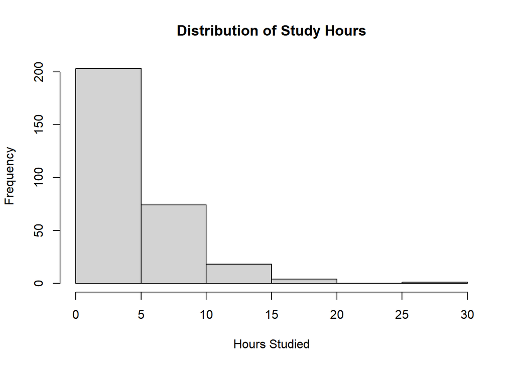

```r
# generating study hours through exponential distribution then creating a histogram and reading the summary
study_hours = rexp(n_students, rate = 1/4)
hist(study_hours, main = "Distribution of Study Hours", xlab = "Hours Studied")
```

```r
summary(study_hours)
```

```
    Min.  1st Qu.   Median     Mean  3rd Qu.     Max.
 0.01747  1.27188  3.36918  4.06096  5.91868 28.84403
```

```r
# generating the options the group can sample from
status = c("online", "in-person")

# drawing randomly the status of students online or in person by sampling to create group with 150 each
group = sample(rep(status, each = 150))

# generating exam scores using the given formula and simulating the normally distribute errors
epsilon = rnorm(n_students, mean = 0, sd =8)
exam_score = 60 + (1.5*study_hours) + epsilon

# creating the dataframe with the three variables then checking the creating by head
exam_data = data.frame(study_hours = study_hours,
                        group = group,
                        exam_score = exam_score)
head(exam_data)
```

```
  study_hours     group exam_score
1   3.3738290 in-person   64.04737
2   2.3064411    online   54.81631
3   5.3162195    online   69.37398
4   0.1263094    online   50.66150
5   0.2248439    online   59.90330
6   1.2660049 in-person   48.42168
```

**2.2 Visualize the data using ggplot2:**

- Create a scatter plot of `exam_score` versus `study_hours`, with points colored by `group`.
- Make sure to use good design choices, such as adequate labels for the axes and an informative title.

```r
# loading ggplot2 to plot
library(ggplot2)
```

The plot below displays the relationship between how many hours a student studied and their exam scores for 300 students, colored by which group the student is in (Online or In-Person).

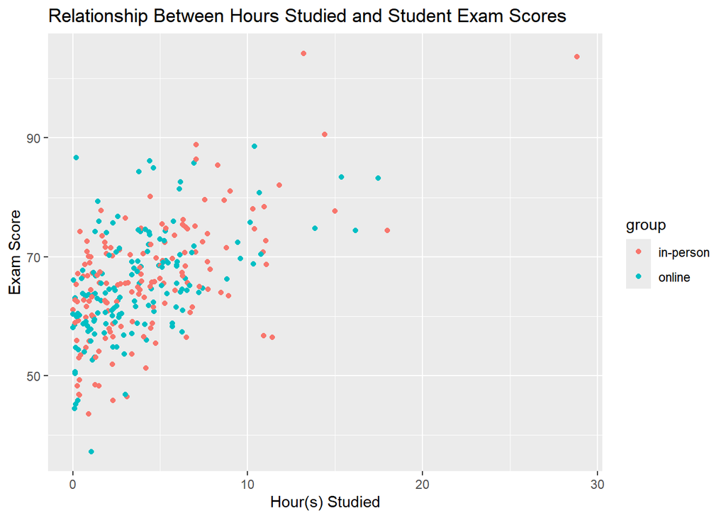

```r
#generating the plot
plot = ggplot(data=exam_data) +
        geom_point(aes(x = study_hours, y = exam_score,
        color = group)) +
        labs(
        title = "Relationship Between Hours Studied and Student Exam Scores",
        x = "Hour(s) Studied",
        y = "Exam Score")
plot
```

**2.3 Describe the plot you generated:**

Describe the plot. Based on the model we used to create exam_score, why is it not surprising that there is no visible difference in exam scores between students attending lectures in person and those watching online?

**Answer**

**Answer**: The plot shows a generally linear trend between the hours a student studied and the exam scores they obtained for a sample of 300 students. This makes sense as we simulated the exam scores to fit along the formula $\text{exam\_score} = 60 + 1.5 \times \text{study\_hours} + \epsilon$, which is a linear equation. The y-intercept seems to be around 60 and the slope seems to be around 1.5, as expected. This means that for every hour more a student studied, 1.5 points more were obtained on their exam. However, even if you studied 0 hours, you would still score around a 60. It was not surprising that there is no visible difference in exam scores between students attending lecture online and in-person as it was a controlled factor that was randomly sampled in our data. Within our formula for exam score, we give no consideration for group type. In the plot you can see that no matter the color, the data points are distributed similarly.

### Question 3: Linear Regression (10 Marks)

For question 3, you will be working with a dataset about dogs in an animal shelter, waiting to be adopted. The dataset contains some information about dogs’ medical history and appearance and a variable `adoption_speed` that indicates how quickly the dog was adopted after being put up for adoption. The higher the value of `adoption_speed`, the quicker the dog was adopted.

The variables in the dataset are:

| Variable | Description |
| --- | --- |
| id | Unique identifier for each dog |
| age | Age of the dog in years |
| vaccinated | Whether the dog is vaccinated (1 = Yes, 0 = No) |
| dewormed | Whether the dog is dewormed (1 = Yes, 0 = No) |
| fur_length | Length of the dog’s fur in centimeters |
| weight | Weight of the dog in kilograms |
| adoption_speed | Speed of adoption (higher values indicate faster adoption) |

Assume we know the data generating process (DGP) and the **only** causal relationships between the variables are the ones listed below. Unless otherwise noted all of these effects are linear and additive.

- Vaccination affects adoption speed.
- Deworming affects adoption speed.
- Age affects adoption speed.
- Age affects vaccination status.
- Age affects weight.
- Dogs’ fur length has a non-linear (quadratic) effect on adoption speed.

**3.1 Estimate a linear regression model**

Read in the dataset `dog_data.csv` and inspect it. Translate the DGP into a linear regression model. Read through the description of the DGP carefully and include all variables in the formula that are necessary, making sure they are specified correctly. Estimate the model using the `lm()` function, naming the lm object `dog_lm`.

```r
# load the dataset
dog_data = read.csv("C:\\Users\\zhaom\\Documents\\GitHub\\ME314\\midterm\\dog_data.csv", header=TRUE)

# inspection for first 6 rows and the structure of the dataframe and a summary of the variables
head(dog_data)
```

```
  id age vaccinated dewormed fur_length   weight adoption_speed
1  1  15          0        1   31.63667 20.80232       58.60521
2  2  15          0        0   58.11123 25.78050       35.66223
3  3   3          0        0   66.28583 19.88588       48.79598
4  4  14          1        0   48.30661 23.01631       52.92591
5  5   3          0        0   58.58525 20.65876       50.09161
6  6  10          1        1   45.58403 24.99870       62.32790
```

```r
str(dog_data)
```

```
'data.frame':   1000 obs. of  7 variables:
 $ id            : int  1 2 3 4 5 6 7 8 9 10 ...
 $ age           : int  15 15 3 14 3 10 2 6 11 5 ...
 $ vaccinated    : int  0 0 0 1 0 1 0 0 1 1 ...
 $ dewormed      : int  1 0 0 0 0 1 1 0 1 1 ...
 $ fur_length    : num  31.6 58.1 66.3 48.3 58.6 ...
 $ weight        : num  20.8 25.8 19.9 23 20.7 ...
 $ adoption_speed: num  58.6 35.7 48.8 52.9 50.1 ...
```

```r
summary(dog_data)
```

```
       id              age          vaccinated      dewormed
 Min.   :   1.0   Min.   : 1.00   Min.   :0.00   Min.   :0.000
 1st Qu.: 250.8   1st Qu.: 5.00   1st Qu.:0.00   1st Qu.:0.000
 Median : 500.5   Median : 8.00   Median :0.00   Median :0.000
 Mean   : 500.5   Mean   : 8.08   Mean   :0.26   Mean   :0.493
 3rd Qu.: 750.2   3rd Qu.:12.00   3rd Qu.:1.00   3rd Qu.:1.000
 Max.   :1000.0   Max.   :15.00   Max.   :1.00   Max.   :1.000
   fur_length        weight      adoption_speed
 Min.   :11.75   Min.   :13.00   Min.   :21.02
 1st Qu.:42.98   1st Qu.:19.77   1st Qu.:48.69
 Median :50.20   Median :21.55   Median :54.06
 Mean   :49.80   Mean   :21.62   Mean   :54.01
 3rd Qu.:56.39   3rd Qu.:23.59   3rd Qu.:60.10
 Max.   :88.52   Max.   :31.34   Max.   :78.13
```

```r
# running a linear regression specifying the formula as a linear function of vaccination status, deworming status, age, and a quadratic function of fur length on adoption speed as for the DGP specified.
dog_lm = lm(formula = adoption_speed~ vaccinated + dewormed + age + fur_length + I(fur_length^2), data = dog_data) %>% summary()
dog_lm
```

```
Call:
lm(formula = adoption_speed ~ vaccinated + dewormed + age + fur_length +
    I(fur_length^2), data = dog_data)

Residuals:
     Min       1Q   Median       3Q      Max
-11.1944  -2.0111  -0.0404   2.0191   8.8926

Coefficients:
                  Estimate Std. Error t value Pr(>|t|)
(Intercept)     82.9017178  1.5257756  54.334  < 2e-16 ***
vaccinated       4.8300087  0.2256282  21.407  < 2e-16 ***
dewormed         1.2953737  0.1874433   6.911  8.6e-12 ***
age             -0.8946105  0.0236688 -37.797  < 2e-16 ***
fur_length      -0.2277529  0.0619795  -3.675 0.000251 ***
I(fur_length^2) -0.0047264  0.0006201  -7.622  5.8e-14 ***
---
Signif. codes:  0 '***' 0.001 '**' 0.01 '*' 0.05 '.' 0.1 ' ' 1

Residual standard error: 2.961 on 994 degrees of freedom
Multiple R-squared:  0.8778,    Adjusted R-squared:  0.8772
F-statistic:  1429 on 5 and 994 DF,  p-value: < 2.2e-16
```

The table above displays the coefficient values of the regression for adoption speed.

**3.2 Interpret the Regression Output**

Interpret the coefficient on age, both in terms of magnitude and statistical significance.

**Answer**

**Answer**: The -0.8946105 coefficient on age means that there is a negative relationship between age and adoption speed (with the other counfounders of: vaccination status, deworming status, and fur length controlled). For every year the dog ages, its speed of adoption goes down 0.894 units in value. The p-value of <2e-16 indicates this finding is very signifigant to the model and the null hypothesis of age not affecting adoption speed should not be accepted. There is a very high probability that age affects adoption speed.

### Question 4: Causal Inference (10 Marks)

For question 4 you will continue working with the dogs dataset from the previous question, but now you will estimate the causal effect of vaccination on adoption speed.

**4.1 Causal Graph**

Create a DAG-like graph to illustrate the causal relationships in the data. Use the `ggdag` package to create a DAG that includes all variables in the DGP. You don’t need to interpret the output. Tip: use abbreviated variable names (2-4 letters) to make the graph readable.

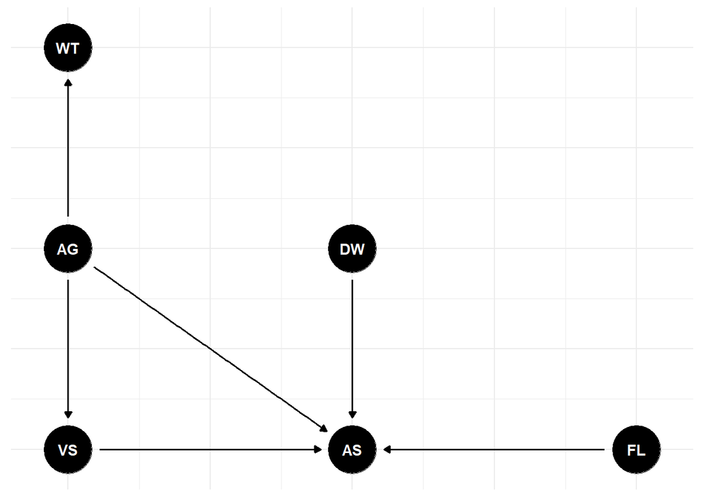

```r
# loading neccesary packages
library(ggdag)
# creating my dag and seeting the coordinates
# key for the dag:
    # AG = age
    # VS = vaccination status
    # DW - deworming status
    # FL = fur length
    # WT = weight
    # AS = adoption speed

DAG = dagify(AS ~ VS + DW + AG + FL,
  VS~AG,
  WT~AG,
  coords = list(x= c(WT = 2, AG = 2, VS = 2, DW = 4, AS = 4, FL = 6),
  y =c(WT = 6, AG = 4, VS = 2, DW = 4, AS = 2, FL = 2)))

# ploting the DAG
DAGp = ggdag(DAG) +
        theme_minimal()+
        remove_axes()
DAGp
```

The figure above shows the relationships of the variables within the dog dataset.

**4.2 Balance Table**

Create a balance table for the predictor variables in your model and interpret the results. You should also draw on your knowledge about the DGP when interpreting the balance table. (Tip: if you use `modelsummary::datasummary_balance()` and get an error when compiling the quarto document with the balance table, specifying the option `output = "markdown"` may fix the error.)

```r
# loading the library

library(modelsummary)

# creating a dataframe without adoption speed as that is our variable of interest an without id as it doesn't affect anything, its just an identifier
dog_data2 = dog_data %>%
    select(-c(adoption_speed, id))
head(dog_data2)
```

```
  age vaccinated dewormed fur_length   weight
1  15          0        1   31.63667 20.80232
2  15          0        0   58.11123 25.78050
3   3          0        0   66.28583 19.88588
4  14          1        0   48.30661 23.01631
5   3          0        0   58.58525 20.65876
6  10          1        1   45.58403 24.99870
```

```r
# getting the data summary table
datasummary_balance(
    ~vaccinated,
    data = dog_data2,
    stars = T
)
```

|  | 0 Mean | 0 Std. Dev. | 1 Mean | 1 Std. Dev. | Diff. in Means | Std. Error |
| --- | --- | --- | --- | --- | --- | --- |
| age | 7.3 | 4.2 | 10.4 | 3.4 | 3.1*** | 0.3 |
| dewormed | 0.5 | 0.5 | 0.5 | 0.5 | -0.0 | 0.0 |
| fur_length | 49.8 | 10.2 | 49.8 | 10.1 | 0.1 | 0.7 |
| weight | 21.4 | 2.9 | 22.3 | 3.0 | 0.9*** | 0.2 |

The table above describes means with or without treatment(vaccination) and the difference in means as well as the standard errors for the variables fur length, age, weight, and deworming status. This is neccesary to determine if any variable is confounding.

**Answer**

**Answer**: The balance sheet shows that there are confounding variables when estimating adoption speed by vaccination status. The difference in means for age(vaccinated dogs are on average 3.1 years older) and weight(vaccinated dogs are on average 0.9 kgs heavier) are signifigant which makes sense as the DGP explicitly states that age is linearly affects adoption speed.

Since age is a cofounder of adoption speed, vaccination status, and weight, it makes sense why weight is also giving some signifigant results. Vaccinated dogs are heavier since age affects weight and older dogs are heavier. However, since the DGP said the relationships listed are the only ones in affect, we know that weight doesn’t affect vaccination status.

Deworming status and fur length don’t have signifigant difference in means between vaccination statuses.

Thus, when running a regression to determine adoption speed from vaccination status, we should control for age.

**4.3 Causal Effect of Vaccination**

Based on your knowledge of the DGP, estimate a model that only includes the variables necessary to identify the effect of vaccination on adoption speed. Explain why you specified the model this way. Finally, calculate 95% confidence intervals for the effect of vaccination on adoption speed and interpret them.

```r
# load the library
library(estimatr)
# create a model and control for age
robust_model = lm_robust(adoption_speed~ vaccinated + age, data = dog_data)

# summarize the model and analyze confidence intervals
summary(robust_model)
```

```
Call:
lm_robust(formula = adoption_speed ~ vaccinated + age, data = dog_data)

Standard error type:  HC2

Coefficients:
            Estimate Std. Error t value  Pr(>|t|) CI Lower CI Upper  DF
(Intercept)  59.5981    0.56975 104.604 0.000e+00  58.4800   60.716 997
vaccinated    4.6110    0.58754   7.848 1.086e-14   3.4580    5.764 997
age          -0.8395    0.06395 -13.128 1.984e-36  -0.9649   -0.714 997

Multiple R-squared:  0.1666 ,   Adjusted R-squared:  0.1649
F-statistic: 93.17 on 2 and 997 DF,  p-value: < 2.2e-16
```

```r
confint(robust_model, level = 0.95)
```

```
                 2.5 %     97.5 %
(Intercept) 58.4800313 60.7161236
vaccinated   3.4580165  5.7639268
age         -0.9649439 -0.7139766
```

**Answer**

**Answer**: I chose to create a robust linear regression to model the relationship between vaccination status an adoption speed because as seen in my DAG (information from the DGP), there is a backdoor path to adoption speed as age effects both vaccination status and adoption speed(it is a cofounder). By adding age into my model, I can control for this and get only the effect of vaccination of adoption speed.

The 95% confidence interval results suggest that if the dogs are not vaccinated (VS=0) and are 0 years old within this distribtuion, we are 95% sure their adoption speed is between 58.48 and 60.72. We are also 95% confident that the true coefficient for vaccination status on adoption speed is between 3.46 to 5.76 units (keeping age constant).